# Clustering 115 Hop Varieties

Tony Ponce

March 26, 2018

# Getting, Cleaning, and Importing Data:

Github doesn’t like to let you download single files, but you can if you want, you will find it in the repository “YCHHopData.csv.” Unfortunately, my webscraping abilities are not up to the level presented by this website (or any other website) for that matter, so, I had to resort to manual entry.

Importing csv as a data frame:

```r
hops <- read.csv("./HopCluster/YCHHopData.csv")
str(hops)
```

```
## 'data.frame':    121 obs. of  25 variables:
##  $ Variety              : Factor w/ 121 levels "Admiral","Ahtanum",..: 1 2 3 4 5 6 7 8 9 10 ...
##  $ Country              : Factor w/ 8 levels "AU","CZ","DE",..: 7 8 8 4 6 8 3 6 7 8 ...
##  $ Class                : Factor w/ 3 levels "A","B","D": 2 1 1 1 3 3 1 1 3 2 ...
##  $ AALow.pct            : num  13 3.5 7 7.9 7 12 9 3.5 5 15 ...
##  $ AAHigh.pct           : num  0 6.5 11 8.3 13 14.5 12 7 7 18 ...
##  $ BALow.pct            : num  4 4 5.5 3.8 2.7 4.5 4.5 4 2.3 3.5 ...
##  $ BAHigh.pct           : num  6 6 8 4.5 4.4 6 5.5 6.1 3.2 5.5 ...
##  $ TOLow.mL100g         : num  0 0.5 1 1.2 0.9 1 1.2 0.7 0.7 2.3 ...
##  $ TOHigh.mL100g        : num  1.7 1.7 2.3 1.6 1.6 2 1.5 4 1 3.5 ...
##  $ CohumuloneLow.pct    : int  37 30 20 20 20 36 22 27 33 28 ...
##  $ CohumuloneHigh.pct   : int  45 34 24 21 26 41 26 31 35 35 ...
##  $ BPineneLow.pct       : num  NA 0.6 0.4 NA NA 0.6 NA NA NA 0.8 ...
##  $ BPineneHigh.pct      : num  NA 0.9 0.8 NA NA 0.9 NA NA NA 1 ...
##  $ MyrceneLow.pct       : int  39 45 45 39 20 45 50 30 35 55 ...
##  $ MyrceneHigh.pct      : int  48 55 50 41 25 55 75 45 37 60 ...
##  $ LinaloolLow.pct      : num  NA 0.4 0.5 NA NA 0.4 NA NA NA 0.4 ...
##  $ LinaloolHigh.pct     : num  NA 0.6 0.8 NA NA 0.7 NA NA NA 0.6 ...
##  $ CaryophylleneLow.pct : num  6 9 7 7.3 6 7 0 4 14.9 6 ...
##  $ CaryophylleneHigh.pct: num  8 12 10 7.5 9 11 2 6 15.1 8 ...
##  $ FarnseneLow.pct      : num  0 0.5 6 2 5 0.5 0.5 4 0.5 0.5 ...
##  $ FarnseneHigh.pct     : num  2 0.5 9 4 10 0.5 0.5 7 0.5 0.5 ...
##  $ HumuleneLow.pct      : num  23 15 19 20.9 20 10 0 13 39.9 8 ...
##  $ HumuleneHigh.pct     : num  26 22 24 21.1 25 18 3 19 30.1 11 ...
##  $ GerianolLow.pct      : num  0 0.4 0.1 0 0 0.1 0 0 0 0.7 ...
##  $ GerianolHigh.pct     : num  0 0.7 0.1 0 0 0.1 0 0 0 0.9 ...
```

You can see there are some NA values, but we will get to those in a second.

Naming rows as the hop variety character strings:

```r
row.names(hops) <- hops$Variety
```

Removing records with too little data (10 or more NA values), and hop blends, leaving 115 records:

```r
remove <- c("Falconer's Flight", "Falconer's Flight 7C's", "HBC 472", "Zythos")
hops <- hops[!(row.names(hops) %in% remove),]
hops <- hops[rowSums(is.na(hops)) < 10, ]
```

Changing factors from integer values, to numeric so they are treated as continuous variables:

```r
hops$CohumuloneLow.pct <- as.numeric(hops$CohumuloneLow.pct)
hops$CohumuloneHigh.pct <- as.numeric(hops$CohumuloneHigh.pct)
hops$MyrceneLow.pct <- as.numeric(hops$MyrceneLow.pct)
hops$MyrceneHigh.pct <- as.numeric(hops$MyrceneHigh.pct)
```

Creating new variables that average the high and low variables that will be used as the single value for that hop variety:

```r
library(dplyr)
hops <- mutate(hops, AA = (AALow.pct+AAHigh.pct)/2)
hops <- mutate(hops, BA = (BALow.pct+BAHigh.pct)/2)
hops <- mutate(hops, TO = (TOLow.mL100g+TOHigh.mL100g)/2)
hops <- mutate(hops, Cohumulone = (CohumuloneLow.pct+CohumuloneHigh.pct)/2)
hops <- mutate(hops, BPinene = (BPineneLow.pct+BPineneHigh.pct)/2)
hops <- mutate(hops, Myrcene = (MyrceneLow.pct+MyrceneHigh.pct)/2)
hops <- mutate(hops, Linalool = (LinaloolLow.pct+LinaloolHigh.pct)/2)
hops <- mutate(hops, Caryophyllene = (CaryophylleneLow.pct+CaryophylleneHigh.pct)/2)
hops <- mutate(hops, Farnsene = (FarnseneLow.pct+FarnseneHigh.pct)/2)
hops <- mutate(hops, Humulene = (HumuleneLow.pct+HumuleneHigh.pct)/2)
hops <- mutate(hops, Gerianol = (GerianolLow.pct+GerianolHigh.pct)/2)
```

Preserving row names, an unfortunate necessity with dplyr:

```r
row.names(hops) <- hops$Variety
```

Subsetting to remove variables no longer required:

```r
hops <- hops[c(-1,-(4:25))]
```

# Imputing NA Values:

Loading the Hmisc package, setting seed, imputing:

```r
library(Hmisc)
set.seed(127)

aregInfo <- aregImpute(~ AA + BA + TO + Cohumulone + BPinene + Myrcene + Linalool +
                             Caryophyllene + Farnsene + Humulene + Gerianol,
                       data = hops, n.impute=10, nk=5, match = "kclosest")
```

```
## Iteration 1
```

```
## Iteration 2
```

```
## Iteration 3
```

```
## Iteration 4
```

```
## Iteration 5
```

```
## Iteration 6
```

```
## Iteration 7
```

```
## Iteration 8
```

```
## Iteration 9
```

```
## Iteration 10
Iteration 11
```

```
## Iteration 12
```

```
## Iteration 13
```

Lets look at the R squared values:

```r
print(aregInfo)
```

```
##
## Multiple Imputation using Bootstrap and PMM
##
## aregImpute(formula = ~AA + BA + TO + Cohumulone + BPinene + Myrcene +
##     Linalool + Caryophyllene + Farnsene + Humulene + Gerianol,
##     data = hops, n.impute = 10, nk = 5, match = "kclosest")
##
## n: 115   p: 11   Imputations: 10     nk: 5
##
## Number of NAs:
##            AA            BA            TO    Cohumulone       BPinene
##             0             0             0             1            66
##       Myrcene      Linalool Caryophyllene      Farnsene      Humulene
##             1            55             2             3             1
##      Gerianol
##             0
##
##               type d.f.
## AA               s    4
## BA               s    4
## TO               s    4
## Cohumulone       s    4
## BPinene          s    4
## Myrcene          s    4
## Linalool         s    4
## Caryophyllene    s    4
## Farnsene         s    4
## Humulene         s    1
## Gerianol         s    2
##
## Transformation of Target Variables Forced to be Linear
##
## R-squares for Predicting Non-Missing Values for Each Variable
## Using Last Imputations of Predictors
##    Cohumulone       BPinene       Myrcene      Linalool Caryophyllene
##         0.705         1.000         0.878         1.000         0.850
##      Farnsene      Humulene
##         0.722         0.877
```

So there is an issue with the perfect R squared values, which suggests the values are overfit. For this analysis, this is ok and most likely better than a random guess.

Lets fill in NA values to original data frame:

```r
imputed <- impute.transcan(aregInfo, data=hops, imputation=10, list.out=TRUE, pr=FALSE, check=FALSE)
imputedHops <- as.data.frame(do.call(cbind,imputed))
row.names(imputedHops) <- row.names(hops)
```

Ok, now to figure out optimal number of clusters based on either the elbow, silhouette or gap statistic method:

```r
library(factoextra)
```

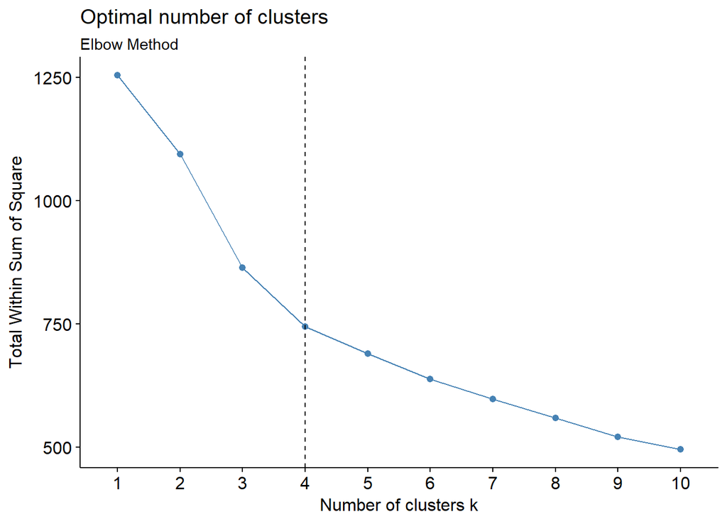

```r
library(NbClust)

scaledhops <- scale(imputedHops)

fviz_nbclust(scaledhops, kmeans, method="wss") +
      geom_vline(xintercept = 4, linetype = 2)+
      labs(subtitle = "Elbow Method")
```

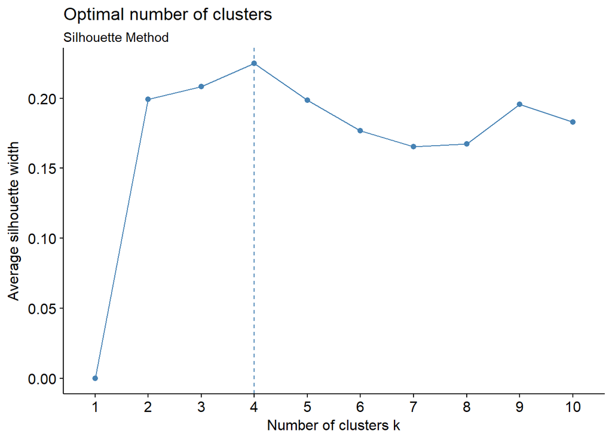

```r
fviz_nbclust(scaledhops, kmeans, method = "silhouette")+
      labs(subtitle = "Silhouette Method")
```

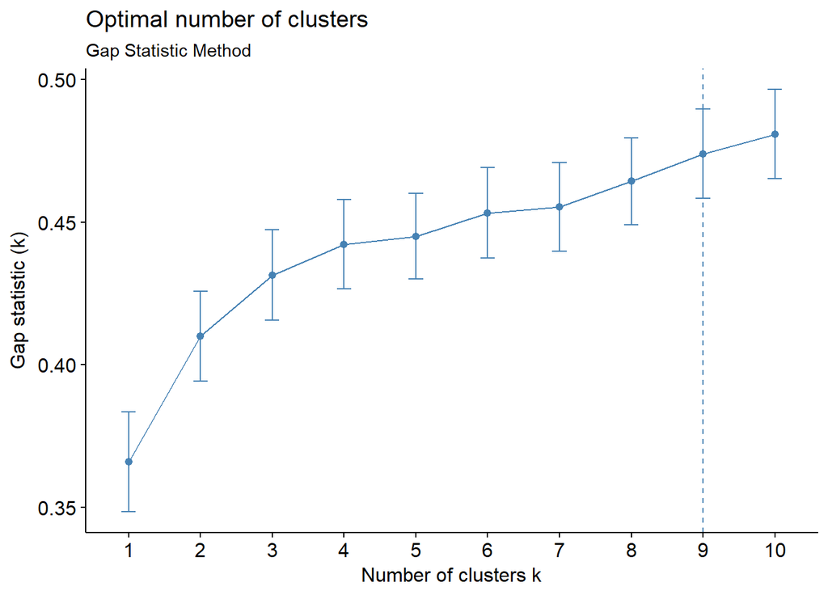

```r
fviz_nbclust(scaledhops, kmeans, nstart = 25,  method = "gap_stat", nboot = 50)+
      labs(subtitle = "Gap Statistic Method")
```

As the elbow and silhouette method would produce and unusable number of clusters, we are going to go with the number suggested by the third method. Nine seems like a good amount for selecting hop varieties.

# Running k-means:

[figure not shown]

```r
library(factoextra)

set.seed(1234)
bob <- kmeans(scale(data.matrix(imputedHops)), centers = 9, nstart = 30)
fviz_cluster(bob, data = imputedHops, main = "HomebrewBytes.com Hop Clusters")
```

Nifty visualization huh? Lets output the groups and distances:

# Output:

```r
kmeansresults <- bob$cluster
# Writing the hop varieties along with the group they belong to:
write.csv(kmeansresults, "./kmeansresults.csv")

# Outputting the distances to csv
sdist <- dist(scale(imputedHops))
newmtx <- data.matrix(sdist)
write.csv(newmtx, "./HopCluster/distances.csv")
```

Unfortunately, my programming skills are not up to ranking the hop names against to the measured distance. To recreate this, sort the distances csv by the 2nd column, copy the sorted row names (leftmost column with hop names) into the values of the column you just sorted, and then copy that entire column into a separate sheet. You should see the hop name at the top, along with the same hop repeated. Do the same for all columns and then transpose to have the same file as shown in the repo: hop-results-clusters.xlsx